# BANA 7050 Time series and Forecasting Assignment 3

Global Temperature Anomalies

Author

VARSHA KURUVA

### Section 1:

#### **Basic EDA and Data Generating Process :**

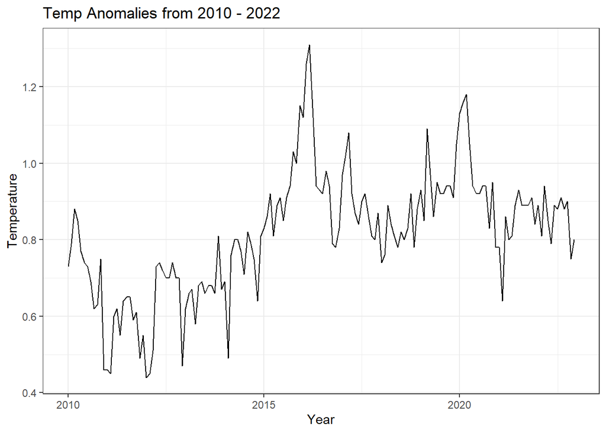

```r
data_monthly %>%
ggplot() +
  geom_line(aes(Year, Value)) +
  theme_bw() +
  ggtitle("Temp Anomalies from 2010 - 2022") +
  xlab("Year") +
  ylab("Temperature")
```

#### **Facebook Prophet Model :**

A facebook prophet model decomposes the time series data into multiple components : trend, seasonality and holidays. The trend component helps us understand the magnitude of change over time.The seasonality component helps us understand repeating patterns over fixed intervals , in our case it is yearly. Because the data we are considering is global temperature anomalies data , special events should not have a drastic impact on it.The trend is modeled using a Bayesian structural time-series model that considers historical trends and seasonality, including changepoints. This approach allows for flexible modeling of seasonal patterns and any irregular patterns in the data.

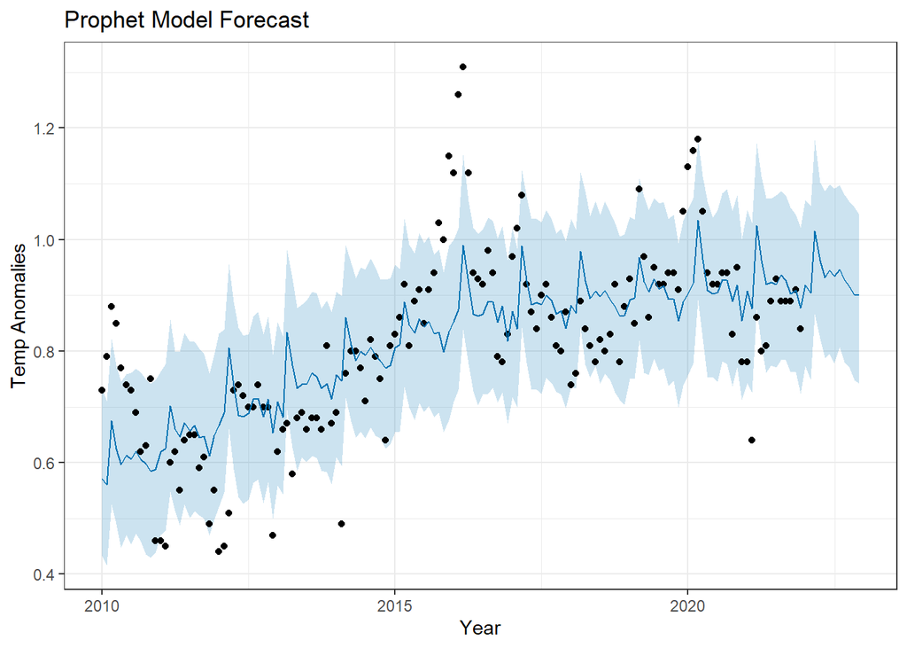

```r
prophet_data = data_monthly %>%
    rename(ds = Year, # Have to name our date variable "ds"
    y = Value)  # Have to name our time series "y"

train = prophet_data %>%  # Train set
  filter(ds<ymd("2022-01-01"))

test = prophet_data %>% # Test set
  filter(ds>=ymd("2022-01-01"))

orig_model = prophet(train) # Train Model

orig_future = make_future_dataframe(orig_model,periods = 12,freq='month')

orig_forecast = predict(orig_model,orig_future) # Get forecast

plot(orig_model,orig_forecast)+
  ylab("Temp Anomalies")+
  xlab("Year")+
  theme_bw()+
  ggtitle("Prophet Model Forecast")
```

### **Section 2 :**

Here, we try and decompose the facebook prophet model. The decomposition of the prophet model shows the presence of seasonality and the trend line mostly resonates with the trend in our data.

The initial model comes with the following parameters: number of changepoints = 25, changepoint prior scale = 0.05, changepoint range = 0.8.

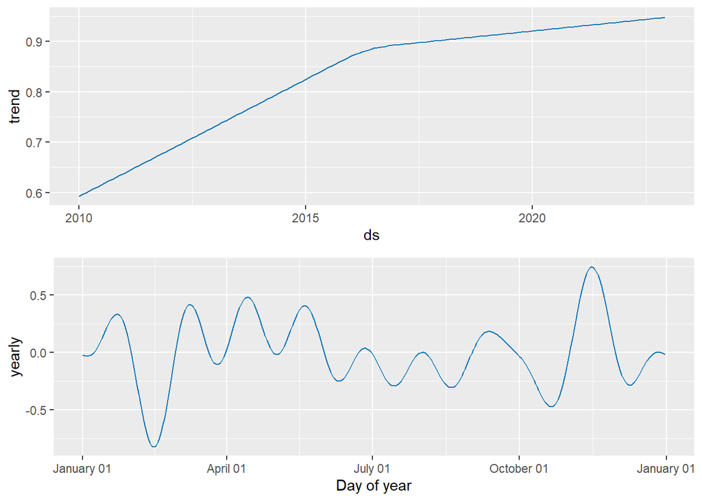

```r
prophet_plot_components(orig_model,orig_forecast)
```

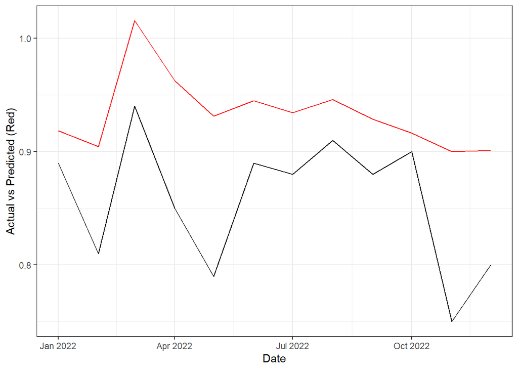

```r
forecast_plot_data = orig_forecast %>%
  as_tibble() %>%
  mutate(ds = as.Date(ds)) %>%
  filter(ds>=ymd("2022-01-01"))

ggplot()+
geom_line(aes(test$ds,test$y))+
geom_line(aes(forecast_plot_data$ds,forecast_plot_data$yhat),color='red')+
theme_bw()+
ylab('Actual vs Predicted (Red)')+
xlab('Date')
```

#### **Original Model : 25 Changepoints**

Change points for initial model or original model. For the original model which has 25 change points , we notice that the change points are accumulated right after the year 2015, which resonates with the trend in the data which shows a substantial spike after 2015, this is because in the latter half of 2015 and 2016, the El Nino event had a direct impact on the increase in global earth temperature which caused the highest temperature fluctuation ever recorded but it does not accurately capture all the trends in our data.

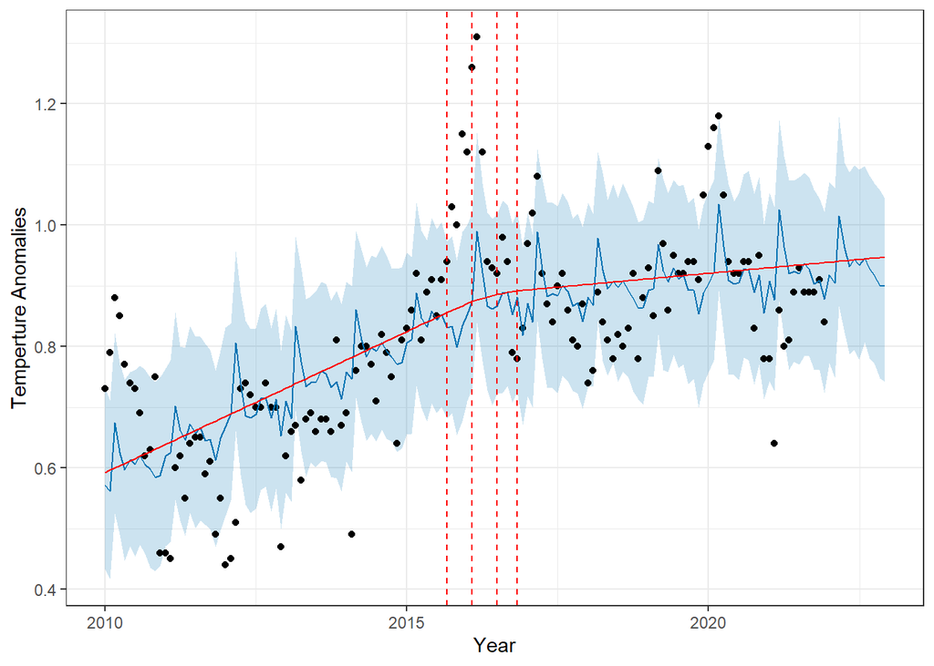

```r
plot(orig_model,orig_forecast) +
  add_changepoints_to_plot(orig_model) +
  theme_bw() +
  xlab("Year") +
  ylab("Temperture Anomalies")
```

We are well aware that increasing or decreasing the number of changepoints in our data will result in overfitting or underfitting and might throw our bias and variance off guard, to avoid this we need to carefully consider the number of changepoints in a way that it captures the trend in our time series data and does not overfit or underfit at the same time. This is done so that forecasting is more accurate and provides insights into the underlying dynamics of our data because we identify the points where the trend or level of our data changes and then model it as per that.

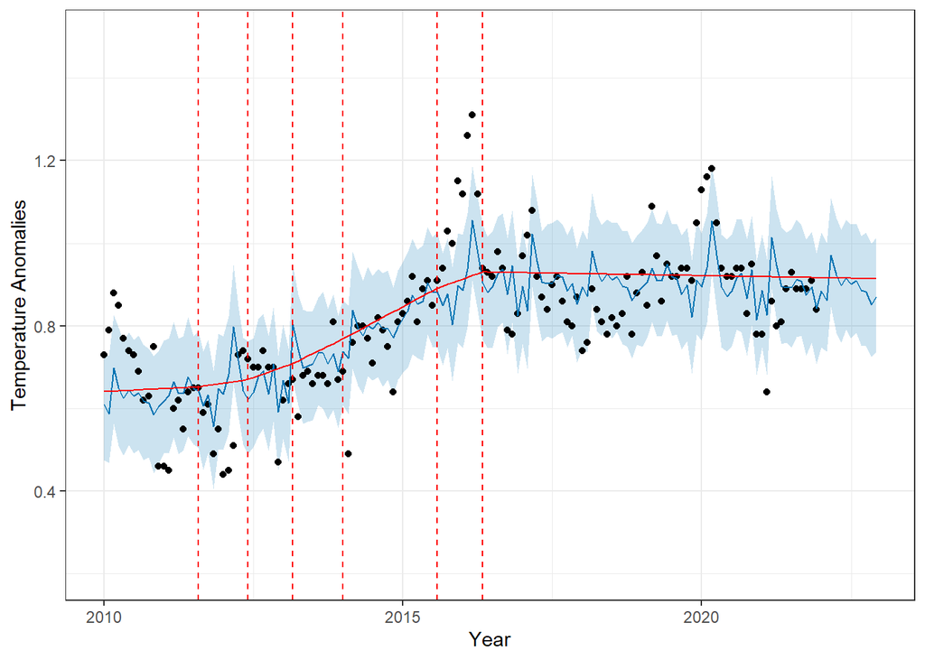

```r
# Number of Changepoints

#model = prophet(train,n.changepoints=10, changepoint.range = 0.9)
model1 = prophet(train,n.changepoints=15, changepoint.range = 1, changepoint.prior.scale = 0.1)


forecast1 = predict(model1,orig_future)

plot(model1,forecast1)+add_changepoints_to_plot(model1)+ylim(0.2,1.5)+theme_bw()+xlab("Year")+ylab("Temperature Anomalies")
```

The trend line below shows us the increasing temperatures globally with a peak in and around the year 2015 which resonates with our time series data. The increasing curve with slight dips indicates the trend.The decomposition of the model also confirms the presence of yearly seasonality in our data.

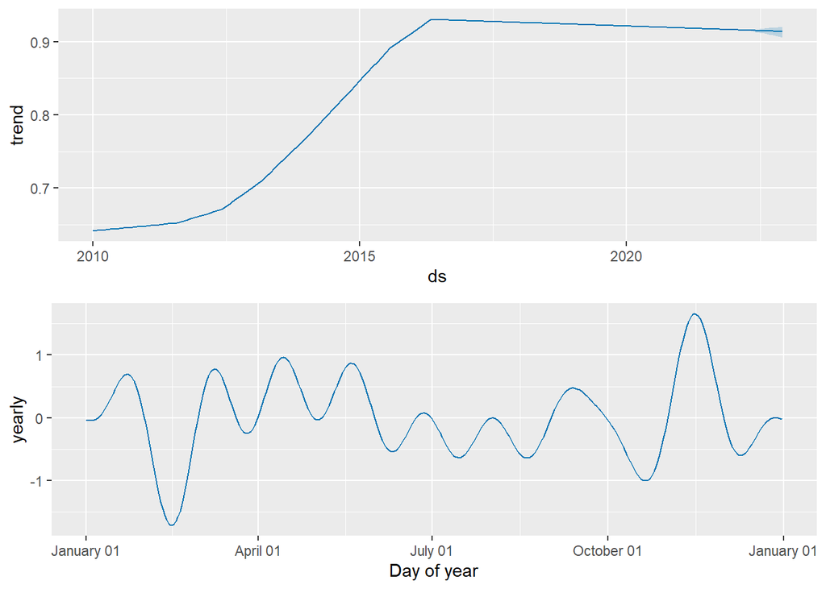

```r
prophet_plot_components(model1, forecast1)
```

#### **Two Year forecast :**

The data set in our hand is that of global temperature anomalies , we can never know or predict how much our temperature changes can vary by because it depends on external factors that mortal beings have little to no control over.For this reason, I believe specifying saturating minimum and maximum points for this data set will not be necessary.

This can also be used to determine that our growth is linear and not logistic because we are not including saturation minimum or maximum in our data.

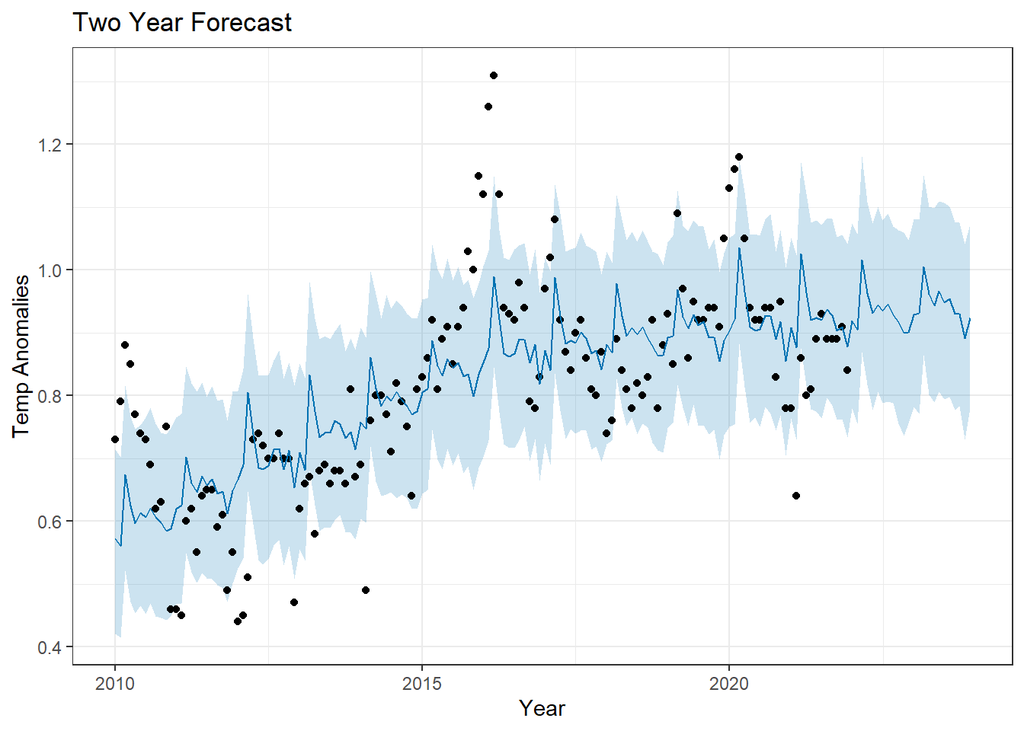

```r
two_yr_future = make_future_dataframe(orig_model,periods = 24,freq='months')
two_yr_forecast = predict(orig_model,two_yr_future)
plot(orig_model,two_yr_forecast)+
  theme_bw()+
  xlab("Year")+
  ylab("Temp Anomalies")+
  ggtitle("Two Year Forecast")
```

### **Section 3 :**

#### **Seasonality Check:**

From the plot of trend & seasonal decomposition of the prophet model, we see a visible upward trend and a yearly seasonal component.

We further assess this seasonal component of the data and better understand the additive or the multiplicative nature of the time-series data.

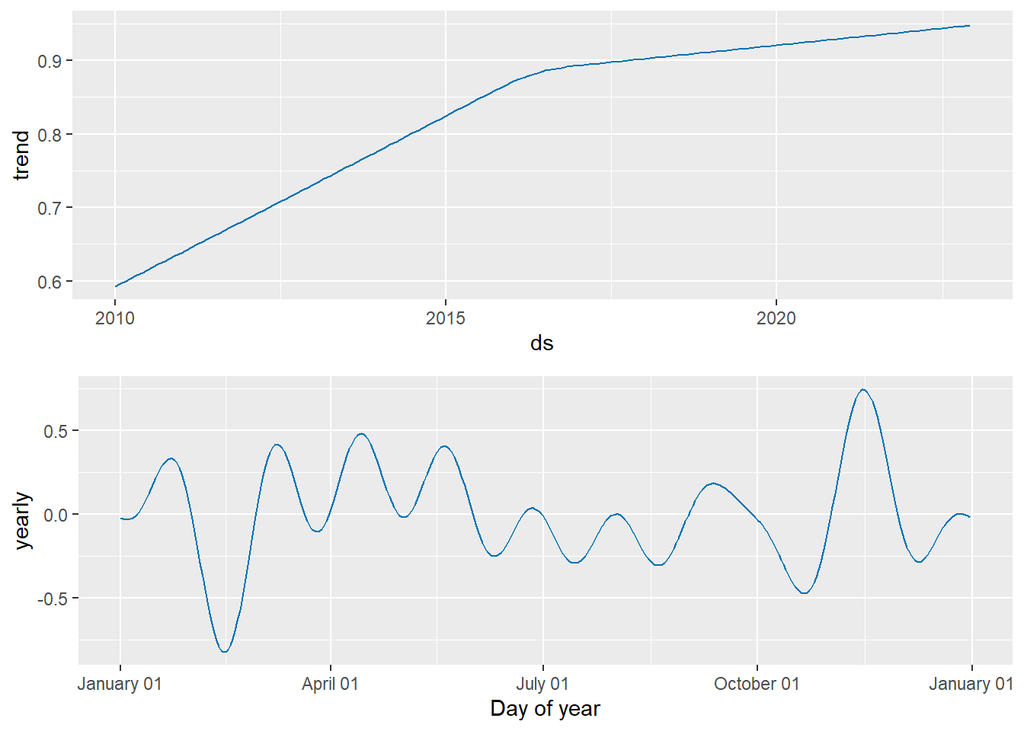

```r
prophet_plot_components(orig_model,orig_forecast)
```

**Comparing additive and multiplicative Seasonality :**

From the below RMSE values and plots , we can conclude that either of the seasonality works but the difference in RMSE values is negligible ,therefore we prefer additive seasonality over multiplicative.

Since we don’t have daily data, we do not have any impact due to holidays.

```r
mod1 = prophet(train,seasonality.mode='additive')
forecast1 = predict(mod1)

mod2 = prophet(train,seasonality.mode='multiplicative')
forecast2 = predict(mod2)

forecast_metric_data_add = forecast1 %>%
  as_tibble() %>%
  mutate(ds = as.Date(ds))

RMSE = sqrt(mean((test$y - forecast_metric_data_add$yhat)^2))

print(paste("RMSE for additive seasonality:",round(RMSE,2)))
```

```
[1] "RMSE for additive seasonality: 0.13"
```

```r
forecast_metric_data_multi = forecast2 %>%
  as_tibble() %>%
  mutate(ds = as.Date(ds))

RMSE = sqrt(mean((test$y - forecast_metric_data_multi$yhat)^2))

print(paste("RMSE for multiplicative seasonality:",round(RMSE,2)))
```

```
[1] "RMSE for multiplicative seasonality: 0.12"
```

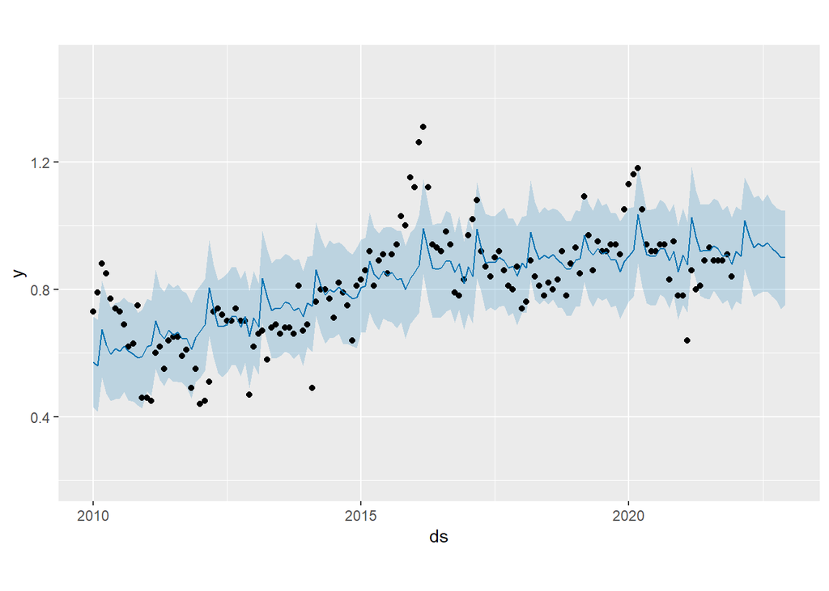

```r
additive = prophet(train)
add_fcst = predict(additive,orig_future)

plot(additive,add_fcst)+
ylim(0.2,1.5)
```

#### **Prophet model for multiplicative seasonality :**

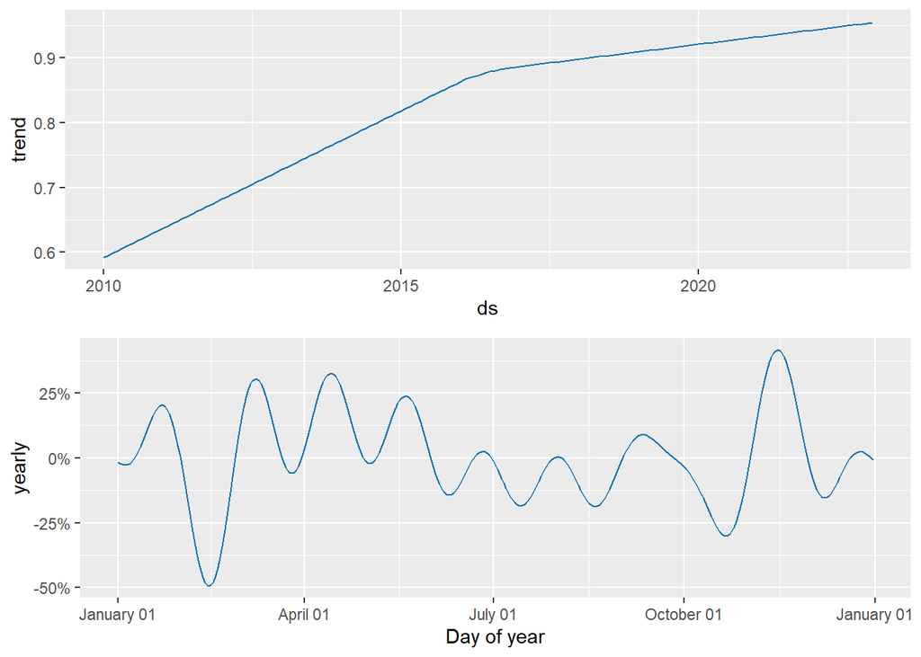

```r
multi = prophet(train,seasonality.mode = 'multiplicative')
multi_fcst = predict(multi,orig_future)

prophet_plot_components(multi,multi_fcst,plot_cap = FALSE)
```

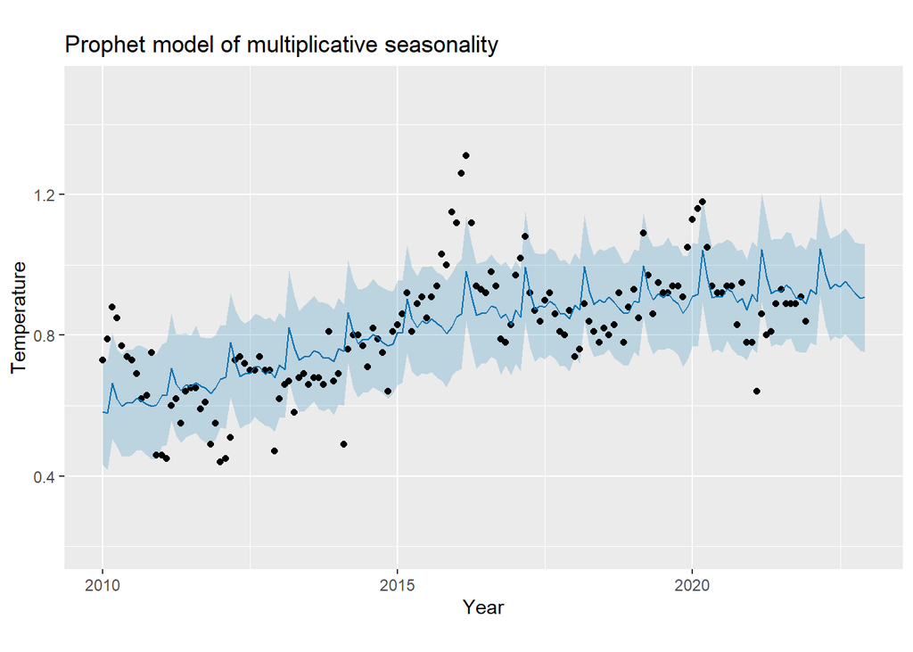

```r
plot(multi,multi_fcst)+ylim(0,5)+ggtitle("Prophet model of multiplicative seasonality")+ylab("Temperature")+xlab("Year")+ylim(0.2,1.5)
```

### Section 4 :

#### **Model Validation :**

Considering that we already established that the time series data at hand has additive seasonality and is the growth is linear, we will try to compare other aspects in models below.It has been observed that our changepoint model has the least MAE,RMSE,MAPE values of all the models that we have compared till this point.

```r
df.cv <- cross_validation(additive, initial = 10*365, period = 30, horizon = 180, units = 'days')
#head(df.cv)

unique(df.cv$cutoff)
```

```
 [1] "2020-01-11 GMT" "2020-02-10 GMT" "2020-03-11 GMT" "2020-04-10 GMT"
 [5] "2020-05-10 GMT" "2020-06-09 GMT" "2020-07-09 GMT" "2020-08-08 GMT"
 [9] "2020-09-07 GMT" "2020-10-07 GMT" "2020-11-06 GMT" "2020-12-06 GMT"
[13] "2021-01-05 GMT" "2021-02-04 GMT" "2021-03-06 GMT" "2021-04-05 GMT"
[17] "2021-05-05 GMT" "2021-06-04 GMT"
```

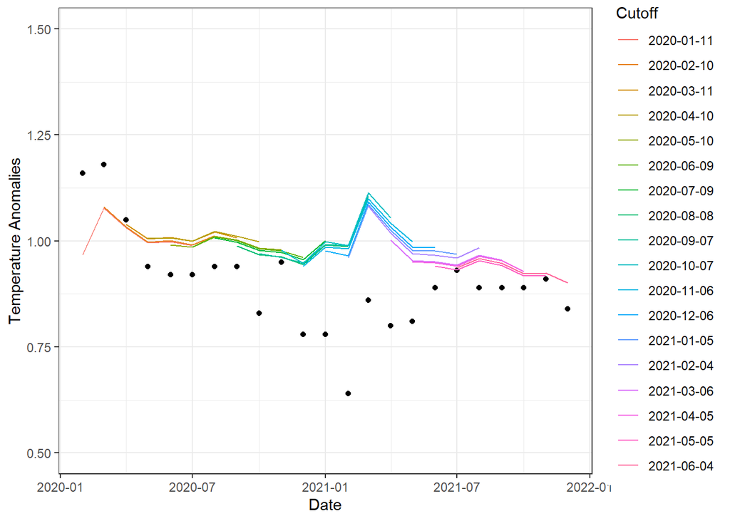

```r
df.cv %>%
  ggplot()+
  geom_point(aes(ds,y)) +
  geom_line(aes(ds,yhat,color=factor(cutoff)),size=0.5, alpha = 10)+
  theme_bw()+
  xlab("Date")+
  ylab("Temperature Anomalies")+
  scale_color_discrete(name = 'Cutoff')+
  ylim(0.5,1.5)
```

#### **Comparison of 20 change points model v/s 25 change points model :**

The model with 20 change points has been deemed better because of MAPE,MAE and RMSE values.

[figure not shown]

```r
old_changepoint_mod = prophet::prophet(train)
df_cv1 <- cross_validation(additive, initial = 10*365, period = 30, horizon = 180, units = 'days')
metrics1 = performance_metrics(df_cv1, rolling_window = 0.3) %>%
  mutate(model = 'Additive')
df_cv2 <- cross_validation(multi, initial = 10*365, period = 30, horizon =180, units = 'days')
metrics2 = performance_metrics(df_cv2, rolling_window = 0.3) %>%
  mutate(model = "Multiplivative")

df_cv5 <- cross_validation(old_changepoint_mod, initial = 10*365, period = 30, horizon = 180, units = 'days')
metrics5 = performance_metrics(df_cv5, rolling_window = 0.3) %>%
  mutate(model = '25 changepoints')

new_changepoint_mod = prophet::prophet(train, n.changepoints = 20, changepoint.prior.scale = 0.09, changepoint.range = 1)

df_cv6 <- cross_validation(new_changepoint_mod, initial = 10*365, period = 30, horizon = 180, units = 'days')
metrics6 = performance_metrics(df_cv6, rolling_window = 0.3) %>%
  mutate(model = "20 changepoints")


g7=metrics5 %>%
bind_rows(metrics6) %>%
ggplot()+
geom_line(aes(horizon,rmse,color=model))+
  theme_bw()+
  xlab("Horizon (months)")+
  ylab("RMSE")

g8 = metrics5 %>%
bind_rows(metrics6) %>%
ggplot()+
geom_line(aes(horizon,mae,color=model))+
  theme_bw()+
  xlab("Horizon (months)")+
  ylab("MAE")

g9 = metrics5 %>%
bind_rows(metrics6) %>%
ggplot()+
geom_line(aes(horizon,mape,color=model))+
  theme_bw()+
  xlab("Horizon (months)")+
  ylab("MAPE")

grid_arrange_shared_legend(g7, g8, g9, ncol = 2, nrow = 2, position='right', top = "Comparison with 25 & 20 changepoints")
```

#### **Changepoint model v/s additive model :**

The changepoint model has been deemed better because of MAPE,MAE and RMSE values.

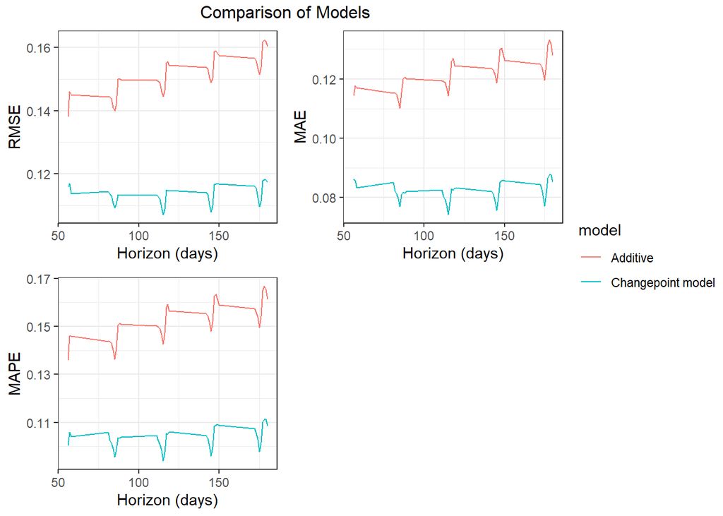

```r
df_cvc <- cross_validation(model1, initial = 10*365, period = 30, horizon = 180, units = 'days')
metrics2 = performance_metrics(df_cvc, rolling_window = 0.3) %>%
  mutate(model = "Changepoint model")

df_cva <- cross_validation(additive, initial = 10*365, period = 30, horizon = 180, units = 'days')
metrics3 = performance_metrics(df_cva, rolling_window = 0.3) %>%
  mutate(model = "Additive")


g1=metrics2 %>%
bind_rows(metrics3) %>%
ggplot()+
geom_line(aes(horizon,rmse,color=model))+
  theme_bw()+
  xlab("Horizon (days)")+
  ylab("RMSE")

g2 = metrics2 %>%
bind_rows(metrics3) %>%
ggplot()+
geom_line(aes(horizon,mae,color=model))+
  theme_bw()+
  xlab("Horizon (days)")+
  ylab("MAE")

g3 = metrics2 %>%
bind_rows(metrics3) %>%
ggplot()+
geom_line(aes(horizon,mape,color=model))+
  theme_bw()+
  xlab("Horizon (days)")+
  ylab("MAPE")

lemon::grid_arrange_shared_legend(g1, g2, g3, ncol = 2, nrow = 2, position='right', top = "Comparison of Models")
```

#### **6 month Prophet Forecast :**

The 6 month forecast looks good as it does capture the underlying trend in our data.

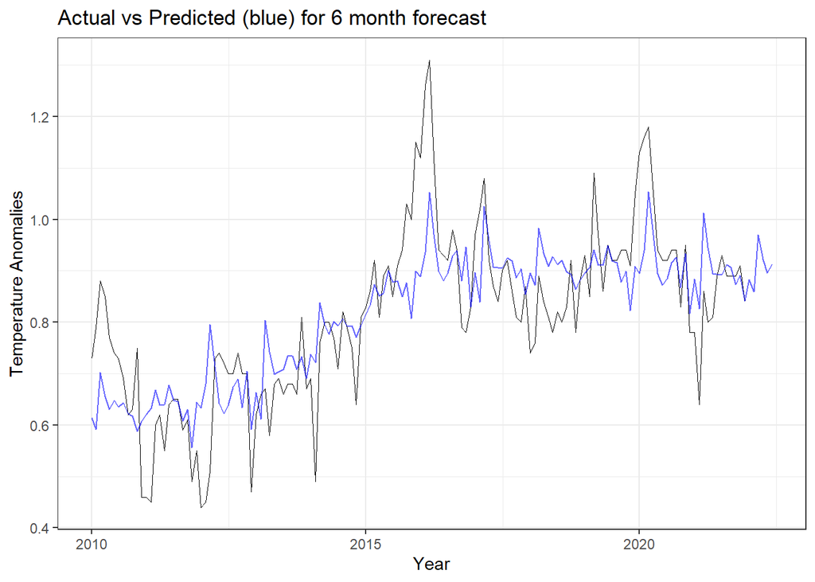

```r
best_fit_model = prophet::prophet(train,growth = 'linear', seasonality.mode = 'additive', n.changepoints=20, changepoint.range = 1, changepoint.prior.scale = 0.1) # Train Model
best_fit_future = make_future_dataframe(best_fit_model,periods = 6, freq= 'months') # Create future dataframe for predictions

best_fit_forecast = predict(best_fit_model,best_fit_future) # Get forecast

ggplot()+
geom_line(aes(as.Date(train$ds),train$y), size = 0.3)+
geom_line(aes(as.Date(best_fit_forecast$ds),best_fit_forecast$yhat),color='blue', alpha = 0.6)+
theme_bw()+
ylab('Temperature Anomalies')+
xlab('Year')+
ggtitle("Actual vs Predicted (blue) for 6 month forecast")
```